# Risk Factor Analysis

## Outcome Variable

**Outcome Variable:** sstunted

## Predictor Variables

**Intervention Variable:** impsan

**Adjustment Set:**

- arm
- sex
- W_mage
- meducyrs
- feducyrs
- hhwealth_quart
- hfoodsec
- W_mhtcm
- W_nrooms
- W_nchldlt5
- W_parity
- impfloor
- safeh20
- delta_W_mage
- delta_meducyrs
- delta_feducyrs
- delta_hhwealth_quart
- delta_hfoodsec
- delta_W_mhtcm
- delta_W_nrooms
- delta_W_nchldlt5
- delta_W_parity
- delta_impfloor
- delta_safeh20

## Stratifying Variables

The analysis was stratified on these variable(s):

- agecat
- studyid
- country

## Data Summary

| agecat | studyid | country | impsan | sstunted | n_cell | n |
| --- | --- | --- | --- | --- | --- | --- |
| Birth | ki0047075b-MAL-ED | BANGLADESH | 0 | 0 | 36 | 234 |
| Birth | ki0047075b-MAL-ED | BANGLADESH | 0 | 1 | 1 | 234 |
| Birth | ki0047075b-MAL-ED | BANGLADESH | 1 | 0 | 192 | 234 |
| Birth | ki0047075b-MAL-ED | BANGLADESH | 1 | 1 | 5 | 234 |
| Birth | ki0047075b-MAL-ED | BRAZIL | 0 | 0 | 4 | 174 |
| Birth | ki0047075b-MAL-ED | BRAZIL | 0 | 1 | 0 | 174 |
| Birth | ki0047075b-MAL-ED | BRAZIL | 1 | 0 | 163 | 174 |
| Birth | ki0047075b-MAL-ED | BRAZIL | 1 | 1 | 7 | 174 |
| Birth | ki0047075b-MAL-ED | INDIA | 0 | 0 | 97 | 190 |
| Birth | ki0047075b-MAL-ED | INDIA | 0 | 1 | 1 | 190 |
| Birth | ki0047075b-MAL-ED | INDIA | 1 | 0 | 87 | 190 |
| Birth | ki0047075b-MAL-ED | INDIA | 1 | 1 | 5 | 190 |
| Birth | ki0047075b-MAL-ED | NEPAL | 0 | 0 | 1 | 171 |
| Birth | ki0047075b-MAL-ED | NEPAL | 0 | 1 | 0 | 171 |
| Birth | ki0047075b-MAL-ED | NEPAL | 1 | 0 | 164 | 171 |
| Birth | ki0047075b-MAL-ED | NEPAL | 1 | 1 | 6 | 171 |
| Birth | ki0047075b-MAL-ED | PERU | 0 | 0 | 183 | 250 |
| Birth | ki0047075b-MAL-ED | PERU | 0 | 1 | 5 | 250 |
| Birth | ki0047075b-MAL-ED | PERU | 1 | 0 | 60 | 250 |
| Birth | ki0047075b-MAL-ED | PERU | 1 | 1 | 2 | 250 |
| Birth | ki0047075b-MAL-ED | SOUTH AFRICA | 0 | 0 | 210 | 213 |
| Birth | ki0047075b-MAL-ED | SOUTH AFRICA | 0 | 1 | 1 | 213 |
| Birth | ki0047075b-MAL-ED | SOUTH AFRICA | 1 | 0 | 2 | 213 |
| Birth | ki0047075b-MAL-ED | SOUTH AFRICA | 1 | 1 | 0 | 213 |
| Birth | ki0047075b-MAL-ED | TANZANIA, UNITED REPUBLIC OF | 0 | 0 | 108 | 113 |
| Birth | ki0047075b-MAL-ED | TANZANIA, UNITED REPUBLIC OF | 0 | 1 | 5 | 113 |
| Birth | ki0047075b-MAL-ED | TANZANIA, UNITED REPUBLIC OF | 1 | 0 | 0 | 113 |
| Birth | ki0047075b-MAL-ED | TANZANIA, UNITED REPUBLIC OF | 1 | 1 | 0 | 113 |
| Birth | ki1017093-NIH-Birth | BANGLADESH | 0 | 0 | 19 | 28 |
| Birth | ki1017093-NIH-Birth | BANGLADESH | 0 | 1 | 0 | 28 |

[output cut: 166 more lines]

The following strata were considered:

- agecat: 24 months, studyid: ki0047075b-MAL-ED, country: BANGLADESH
- agecat: 24 months, studyid: ki0047075b-MAL-ED, country: BRAZIL
- agecat: 24 months, studyid: ki0047075b-MAL-ED, country: INDIA
- agecat: 24 months, studyid: ki0047075b-MAL-ED, country: NEPAL
- agecat: 24 months, studyid: ki0047075b-MAL-ED, country: PERU
- agecat: 24 months, studyid: ki0047075b-MAL-ED, country: SOUTH AFRICA
- agecat: 24 months, studyid: ki0047075b-MAL-ED, country: TANZANIA, UNITED REPUBLIC OF
- agecat: 24 months, studyid: ki1017093-NIH-Birth, country: BANGLADESH
- agecat: 24 months, studyid: ki1017093b-PROVIDE, country: BANGLADESH
- agecat: 24 months, studyid: ki1017093c-NIH-Crypto, country: BANGLADESH
- agecat: 24 months, studyid: ki1114097-CONTENT, country: PERU
- agecat: 24 months, studyid: ki1135781-COHORTS, country: GUATEMALA
- agecat: 24 months, studyid: ki1135781-COHORTS, country: INDIA
- agecat: 24 months, studyid: ki1135781-COHORTS, country: PHILIPPINES
- agecat: 24 months, studyid: ki1148112-LCNI-5, country: MALAWI
- agecat: 24 months, studyid: kiGH5241-JiVitA-3, country: BANGLADESH
- agecat: 24 months, studyid: kiGH5241-JiVitA-4, country: BANGLADESH
- agecat: 6 months, studyid: ki0047075b-MAL-ED, country: BANGLADESH
- agecat: 6 months, studyid: ki0047075b-MAL-ED, country: BRAZIL
- agecat: 6 months, studyid: ki0047075b-MAL-ED, country: INDIA
- agecat: 6 months, studyid: ki0047075b-MAL-ED, country: NEPAL
- agecat: 6 months, studyid: ki0047075b-MAL-ED, country: PERU
- agecat: 6 months, studyid: ki0047075b-MAL-ED, country: SOUTH AFRICA
- agecat: 6 months, studyid: ki0047075b-MAL-ED, country: TANZANIA, UNITED REPUBLIC OF
- agecat: 6 months, studyid: ki1017093-NIH-Birth, country: BANGLADESH
- agecat: 6 months, studyid: ki1017093b-PROVIDE, country: BANGLADESH
- agecat: 6 months, studyid: ki1017093c-NIH-Crypto, country: BANGLADESH
- agecat: 6 months, studyid: ki1114097-CONTENT, country: PERU
- agecat: 6 months, studyid: ki1135781-COHORTS, country: GUATEMALA
- agecat: 6 months, studyid: ki1135781-COHORTS, country: INDIA
- agecat: 6 months, studyid: ki1135781-COHORTS, country: PHILIPPINES
- agecat: 6 months, studyid: ki1148112-LCNI-5, country: MALAWI
- agecat: 6 months, studyid: kiGH5241-JiVitA-3, country: BANGLADESH
- agecat: 6 months, studyid: kiGH5241-JiVitA-4, country: BANGLADESH
- agecat: Birth, studyid: ki0047075b-MAL-ED, country: BANGLADESH
- agecat: Birth, studyid: ki0047075b-MAL-ED, country: BRAZIL
- agecat: Birth, studyid: ki0047075b-MAL-ED, country: INDIA
- agecat: Birth, studyid: ki0047075b-MAL-ED, country: NEPAL
- agecat: Birth, studyid: ki0047075b-MAL-ED, country: PERU
- agecat: Birth, studyid: ki0047075b-MAL-ED, country: SOUTH AFRICA
- agecat: Birth, studyid: ki0047075b-MAL-ED, country: TANZANIA, UNITED REPUBLIC OF
- agecat: Birth, studyid: ki1017093-NIH-Birth, country: BANGLADESH
- agecat: Birth, studyid: ki1017093c-NIH-Crypto, country: BANGLADESH
- agecat: Birth, studyid: ki1114097-CONTENT, country: PERU
- agecat: Birth, studyid: ki1135781-COHORTS, country: GUATEMALA
- agecat: Birth, studyid: ki1135781-COHORTS, country: INDIA
- agecat: Birth, studyid: ki1135781-COHORTS, country: PHILIPPINES
- agecat: Birth, studyid: kiGH5241-JiVitA-3, country: BANGLADESH
- agecat: Birth, studyid: kiGH5241-JiVitA-4, country: BANGLADESH

### Dropped Strata

Some strata were dropped due to rare outcomes:

- agecat: Birth, studyid: ki0047075b-MAL-ED, country: BANGLADESH
- agecat: Birth, studyid: ki0047075b-MAL-ED, country: BRAZIL
- agecat: Birth, studyid: ki0047075b-MAL-ED, country: INDIA
- agecat: Birth, studyid: ki0047075b-MAL-ED, country: NEPAL
- agecat: Birth, studyid: ki0047075b-MAL-ED, country: PERU
- agecat: Birth, studyid: ki0047075b-MAL-ED, country: SOUTH AFRICA
- agecat: Birth, studyid: ki0047075b-MAL-ED, country: TANZANIA, UNITED REPUBLIC OF
- agecat: Birth, studyid: ki1017093-NIH-Birth, country: BANGLADESH
- agecat: Birth, studyid: ki1017093c-NIH-Crypto, country: BANGLADESH
- agecat: Birth, studyid: ki1114097-CONTENT, country: PERU
- agecat: Birth, studyid: ki1135781-COHORTS, country: GUATEMALA
- agecat: Birth, studyid: ki1135781-COHORTS, country: PHILIPPINES
- agecat: 6 months, studyid: ki0047075b-MAL-ED, country: BANGLADESH
- agecat: 6 months, studyid: ki0047075b-MAL-ED, country: BRAZIL
- agecat: 6 months, studyid: ki0047075b-MAL-ED, country: INDIA
- agecat: 6 months, studyid: ki0047075b-MAL-ED, country: NEPAL
- agecat: 6 months, studyid: ki0047075b-MAL-ED, country: PERU
- agecat: 6 months, studyid: ki0047075b-MAL-ED, country: SOUTH AFRICA
- agecat: 6 months, studyid: ki0047075b-MAL-ED, country: TANZANIA, UNITED REPUBLIC OF
- agecat: 6 months, studyid: ki1017093b-PROVIDE, country: BANGLADESH
- agecat: 6 months, studyid: ki1114097-CONTENT, country: PERU
- agecat: 6 months, studyid: ki1135781-COHORTS, country: GUATEMALA
- agecat: 6 months, studyid: ki1135781-COHORTS, country: PHILIPPINES
- agecat: 6 months, studyid: ki1148112-LCNI-5, country: MALAWI
- agecat: 24 months, studyid: ki0047075b-MAL-ED, country: BANGLADESH
- agecat: 24 months, studyid: ki0047075b-MAL-ED, country: BRAZIL
- agecat: 24 months, studyid: ki0047075b-MAL-ED, country: NEPAL
- agecat: 24 months, studyid: ki0047075b-MAL-ED, country: PERU
- agecat: 24 months, studyid: ki0047075b-MAL-ED, country: SOUTH AFRICA
- agecat: 24 months, studyid: ki0047075b-MAL-ED, country: TANZANIA, UNITED REPUBLIC OF
- agecat: 24 months, studyid: ki1114097-CONTENT, country: PERU
- agecat: 24 months, studyid: ki1148112-LCNI-5, country: MALAWI

## Methods Detail

We’re interested in the causal parameters $E[Y_a]$ for all values of $a \in \mathcal{A}$. These parameters represent the mean outcome if, possibly contrary to fact, we intervened to set all units to have $A=a$. Under the randomization and positivity assumptions, these are identified by the statistical parameters $\psi_a=E_W[E_{Y|A,W}(Y|A=a,W)]$. In addition, we’re interested in the mean of $Y$, $E[Y]$ under no intervention (the observed mean). We will estimate these parameters by using SuperLearner to fit the relevant likelihood factors – $E_{Y|A,W}(Y|A=a,W)$ and $p(A=a|W)$, and then updating our likelihood fit using a joint TMLE.

For unadjusted analyses ($W=\{\}$), initial likelihoods were estimated using Lrnr_glm to estimate the simple $E(Y|A)$ and Lrnr_mean to estimate $p(A)$. For adjusted analyses, a small library containing Lrnr_glmnet, Lrnr_xgboost, and Lrnr_mean was used.

Having estimated these parameters, we will then use the delta method to estimate relative risks and attributable risks relative to a prespecified baseline level of $A$.

# Results Detail

## Results Plots

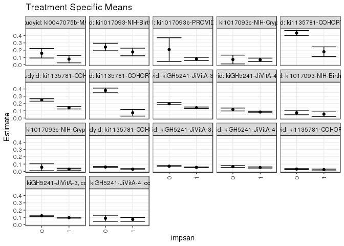

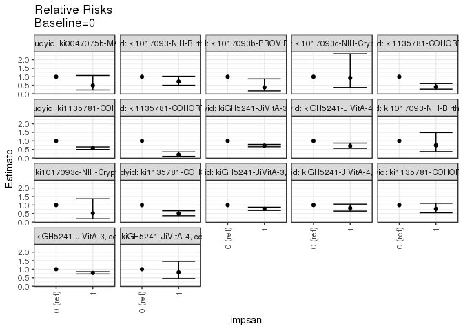

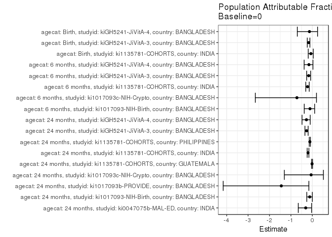

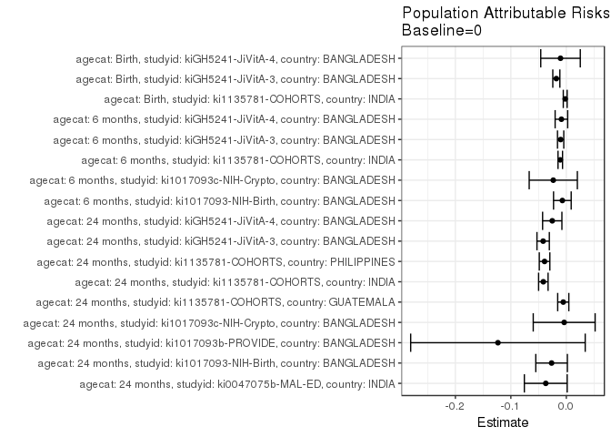

## Results Table

### Parameter: TSM

| agecat | studyid | country | intervention_level | baseline_level | estimate | ci_lower | ci_upper |
| --- | --- | --- | --- | --- | --- | --- | --- |
| Birth | ki1135781-COHORTS | INDIA | 0 | NA | 0.0315094 | 0.0253255 | 0.0376934 |
| Birth | ki1135781-COHORTS | INDIA | 1 | NA | 0.0245224 | 0.0174646 | 0.0315803 |
| Birth | kiGH5241-JiVitA-3 | BANGLADESH | 0 | NA | 0.1221696 | 0.1143743 | 0.1299649 |
| Birth | kiGH5241-JiVitA-3 | BANGLADESH | 1 | NA | 0.0955725 | 0.0900216 | 0.1011234 |
| Birth | kiGH5241-JiVitA-4 | BANGLADESH | 0 | NA | 0.0883097 | 0.0468246 | 0.1297948 |
| Birth | kiGH5241-JiVitA-4 | BANGLADESH | 1 | NA | 0.0719919 | 0.0467448 | 0.0972389 |
| 6 months | ki1017093-NIH-Birth | BANGLADESH | 0 | NA | 0.0722883 | 0.0444065 | 0.1001702 |
| 6 months | ki1017093-NIH-Birth | BANGLADESH | 1 | NA | 0.0536595 | 0.0227837 | 0.0845354 |
| 6 months | ki1017093c-NIH-Crypto | BANGLADESH | 0 | NA | 0.0561798 | 0.0083061 | 0.1040534 |
| 6 months | ki1017093c-NIH-Crypto | BANGLADESH | 1 | NA | 0.0292683 | 0.0159371 | 0.0425994 |
| 6 months | ki1135781-COHORTS | INDIA | 0 | NA | 0.0595586 | 0.0514594 | 0.0676577 |
| 6 months | ki1135781-COHORTS | INDIA | 1 | NA | 0.0297042 | 0.0222473 | 0.0371610 |
| 6 months | kiGH5241-JiVitA-3 | BANGLADESH | 0 | NA | 0.0708736 | 0.0637436 | 0.0780037 |
| 6 months | kiGH5241-JiVitA-3 | BANGLADESH | 1 | NA | 0.0549832 | 0.0507137 | 0.0592527 |
| 6 months | kiGH5241-JiVitA-4 | BANGLADESH | 0 | NA | 0.0645508 | 0.0516053 | 0.0774964 |
| 6 months | kiGH5241-JiVitA-4 | BANGLADESH | 1 | NA | 0.0531300 | 0.0454780 | 0.0607820 |
| 24 months | ki0047075b-MAL-ED | INDIA | 0 | NA | 0.1570248 | 0.0920546 | 0.2219950 |
| 24 months | ki0047075b-MAL-ED | INDIA | 1 | NA | 0.0769231 | 0.0255961 | 0.1282501 |
| 24 months | ki1017093-NIH-Birth | BANGLADESH | 0 | NA | 0.2433246 | 0.1913680 | 0.2952812 |
| 24 months | ki1017093-NIH-Birth | BANGLADESH | 1 | NA | 0.1751556 | 0.1225955 | 0.2277157 |
| 24 months | ki1017093b-PROVIDE | BANGLADESH | 0 | NA | 0.2083333 | 0.0457147 | 0.3709520 |
| 24 months | ki1017093b-PROVIDE | BANGLADESH | 1 | NA | 0.0797101 | 0.0570963 | 0.1023240 |
| 24 months | ki1017093c-NIH-Crypto | BANGLADESH | 0 | NA | 0.0714286 | 0.0110372 | 0.1318199 |
| 24 months | ki1017093c-NIH-Crypto | BANGLADESH | 1 | NA | 0.0669746 | 0.0434058 | 0.0905434 |
| 24 months | ki1135781-COHORTS | GUATEMALA | 0 | NA | 0.4363004 | 0.4025404 | 0.4700603 |
| 24 months | ki1135781-COHORTS | GUATEMALA | 1 | NA | 0.1784434 | 0.1114013 | 0.2454854 |
| 24 months | ki1135781-COHORTS | INDIA | 0 | NA | 0.2483882 | 0.2317590 | 0.2650175 |
| 24 months | ki1135781-COHORTS | INDIA | 1 | NA | 0.1413702 | 0.1249316 | 0.1578088 |
| 24 months | ki1135781-COHORTS | PHILIPPINES | 0 | NA | 0.3796296 | 0.3472541 | 0.4120051 |
| 24 months | ki1135781-COHORTS | PHILIPPINES | 1 | NA | 0.0714286 | 0.0264375 | 0.1164196 |
| 24 months | kiGH5241-JiVitA-3 | BANGLADESH | 0 | NA | 0.1975237 | 0.1833283 | 0.2117190 |
| 24 months | kiGH5241-JiVitA-3 | BANGLADESH | 1 | NA | 0.1423377 | 0.1327967 | 0.1518788 |
| 24 months | kiGH5241-JiVitA-4 | BANGLADESH | 0 | NA | 0.1173696 | 0.0971443 | 0.1375950 |
| 24 months | kiGH5241-JiVitA-4 | BANGLADESH | 1 | NA | 0.0825960 | 0.0721559 | 0.0930361 |

### Parameter: E(Y)

| agecat | studyid | country | intervention_level | baseline_level | estimate | ci_lower | ci_upper |
| --- | --- | --- | --- | --- | --- | --- | --- |
| Birth | ki1135781-COHORTS | INDIA | NA | NA | 0.0295226 | 0.0247216 | 0.0343236 |
| Birth | kiGH5241-JiVitA-3 | BANGLADESH | NA | NA | 0.1041752 | 0.0994998 | 0.1088506 |
| Birth | kiGH5241-JiVitA-4 | BANGLADESH | NA | NA | 0.0778589 | 0.0559066 | 0.0998111 |
| 6 months | ki1017093-NIH-Birth | BANGLADESH | NA | NA | 0.0651769 | 0.0442802 | 0.0860736 |
| 6 months | ki1017093c-NIH-Crypto | BANGLADESH | NA | NA | 0.0326705 | 0.0195292 | 0.0458117 |
| 6 months | ki1135781-COHORTS | INDIA | NA | NA | 0.0486824 | 0.0426994 | 0.0546654 |
| 6 months | kiGH5241-JiVitA-3 | BANGLADESH | NA | NA | 0.0606467 | 0.0567903 | 0.0645031 |
| 6 months | kiGH5241-JiVitA-4 | BANGLADESH | NA | NA | 0.0557144 | 0.0488132 | 0.0626157 |
| 24 months | ki0047075b-MAL-ED | INDIA | NA | NA | 0.1200000 | 0.0774445 | 0.1625555 |
| 24 months | ki1017093-NIH-Birth | BANGLADESH | NA | NA | 0.2167832 | 0.1777459 | 0.2558205 |
| 24 months | ki1017093b-PROVIDE | BANGLADESH | NA | NA | 0.0850694 | 0.0622663 | 0.1078726 |
| 24 months | ki1017093c-NIH-Crypto | BANGLADESH | NA | NA | 0.0675944 | 0.0456333 | 0.0895555 |
| 24 months | ki1135781-COHORTS | GUATEMALA | NA | NA | 0.4308036 | 0.3983616 | 0.4632455 |
| 24 months | ki1135781-COHORTS | INDIA | NA | NA | 0.2069792 | 0.1940174 | 0.2199410 |
| 24 months | ki1135781-COHORTS | PHILIPPINES | NA | NA | 0.3404040 | 0.3108725 | 0.3699356 |
| 24 months | kiGH5241-JiVitA-3 | BANGLADESH | NA | NA | 0.1557596 | 0.1470134 | 0.1645058 |
| 24 months | kiGH5241-JiVitA-4 | BANGLADESH | NA | NA | 0.0920173 | 0.0825478 | 0.1014867 |

### Parameter: RR

| agecat | studyid | country | intervention_level | baseline_level | estimate | ci_lower | ci_upper |
| --- | --- | --- | --- | --- | --- | --- | --- |
| Birth | ki1135781-COHORTS | INDIA | 0 | 0 | 1.0000000 | 1.0000000 | 1.0000000 |
| Birth | ki1135781-COHORTS | INDIA | 1 | 0 | 0.7782570 | 0.5496342 | 1.1019764 |
| Birth | kiGH5241-JiVitA-3 | BANGLADESH | 0 | 0 | 1.0000000 | 1.0000000 | 1.0000000 |
| Birth | kiGH5241-JiVitA-3 | BANGLADESH | 1 | 0 | 0.7822937 | 0.7194857 | 0.8505846 |
| Birth | kiGH5241-JiVitA-4 | BANGLADESH | 0 | 0 | 1.0000000 | 1.0000000 | 1.0000000 |
| Birth | kiGH5241-JiVitA-4 | BANGLADESH | 1 | 0 | 0.8152200 | 0.4538989 | 1.4641666 |
| 6 months | ki1017093-NIH-Birth | BANGLADESH | 0 | 0 | 1.0000000 | 1.0000000 | 1.0000000 |
| 6 months | ki1017093-NIH-Birth | BANGLADESH | 1 | 0 | 0.7422989 | 0.3713110 | 1.4839517 |
| 6 months | ki1017093c-NIH-Crypto | BANGLADESH | 0 | 0 | 1.0000000 | 1.0000000 | 1.0000000 |
| 6 months | ki1017093c-NIH-Crypto | BANGLADESH | 1 | 0 | 0.5209756 | 0.1982366 | 1.3691498 |
| 6 months | ki1135781-COHORTS | INDIA | 0 | 0 | 1.0000000 | 1.0000000 | 1.0000000 |
| 6 months | ki1135781-COHORTS | INDIA | 1 | 0 | 0.4987386 | 0.3750768 | 0.6631714 |
| 6 months | kiGH5241-JiVitA-3 | BANGLADESH | 0 | 0 | 1.0000000 | 1.0000000 | 1.0000000 |
| 6 months | kiGH5241-JiVitA-3 | BANGLADESH | 1 | 0 | 0.7757924 | 0.6866246 | 0.8765399 |
| 6 months | kiGH5241-JiVitA-4 | BANGLADESH | 0 | 0 | 1.0000000 | 1.0000000 | 1.0000000 |
| 6 months | kiGH5241-JiVitA-4 | BANGLADESH | 1 | 0 | 0.8230726 | 0.6459054 | 1.0488353 |
| 24 months | ki0047075b-MAL-ED | INDIA | 0 | 0 | 1.0000000 | 1.0000000 | 1.0000000 |
| 24 months | ki0047075b-MAL-ED | INDIA | 1 | 0 | 0.4898785 | 0.2234156 | 1.0741461 |
| 24 months | ki1017093-NIH-Birth | BANGLADESH | 0 | 0 | 1.0000000 | 1.0000000 | 1.0000000 |
| 24 months | ki1017093-NIH-Birth | BANGLADESH | 1 | 0 | 0.7198433 | 0.5036209 | 1.0288976 |
| 24 months | ki1017093b-PROVIDE | BANGLADESH | 0 | 0 | 1.0000000 | 1.0000000 | 1.0000000 |
| 24 months | ki1017093b-PROVIDE | BANGLADESH | 1 | 0 | 0.3826087 | 0.1667483 | 0.8779063 |
| 24 months | ki1017093c-NIH-Crypto | BANGLADESH | 0 | 0 | 1.0000000 | 1.0000000 | 1.0000000 |
| 24 months | ki1017093c-NIH-Crypto | BANGLADESH | 1 | 0 | 0.9376443 | 0.3752451 | 2.3429402 |
| 24 months | ki1135781-COHORTS | GUATEMALA | 0 | 0 | 1.0000000 | 1.0000000 | 1.0000000 |
| 24 months | ki1135781-COHORTS | GUATEMALA | 1 | 0 | 0.4089920 | 0.2787440 | 0.6001008 |
| 24 months | ki1135781-COHORTS | INDIA | 0 | 0 | 1.0000000 | 1.0000000 | 1.0000000 |
| 24 months | ki1135781-COHORTS | INDIA | 1 | 0 | 0.5691501 | 0.4992427 | 0.6488465 |
| 24 months | ki1135781-COHORTS | PHILIPPINES | 0 | 0 | 1.0000000 | 1.0000000 | 1.0000000 |
| 24 months | ki1135781-COHORTS | PHILIPPINES | 1 | 0 | 0.1881533 | 0.0996472 | 0.3552702 |
| 24 months | kiGH5241-JiVitA-3 | BANGLADESH | 0 | 0 | 1.0000000 | 1.0000000 | 1.0000000 |
| 24 months | kiGH5241-JiVitA-3 | BANGLADESH | 1 | 0 | 0.7206110 | 0.6570070 | 0.7903725 |
| 24 months | kiGH5241-JiVitA-4 | BANGLADESH | 0 | 0 | 1.0000000 | 1.0000000 | 1.0000000 |
| 24 months | kiGH5241-JiVitA-4 | BANGLADESH | 1 | 0 | 0.7037255 | 0.5687115 | 0.8707924 |

### Parameter: PAR

| agecat | studyid | country | intervention_level | baseline_level | estimate | ci_lower | ci_upper |
| --- | --- | --- | --- | --- | --- | --- | --- |
| Birth | ki1135781-COHORTS | INDIA | 0 | NA | -0.0019868 | -0.0054725 | 0.0014989 |
| Birth | kiGH5241-JiVitA-3 | BANGLADESH | 0 | NA | -0.0179944 | -0.0243628 | -0.0116261 |
| Birth | kiGH5241-JiVitA-4 | BANGLADESH | 0 | NA | -0.0104508 | -0.0460935 | 0.0251918 |
| 6 months | ki1017093-NIH-Birth | BANGLADESH | 0 | NA | -0.0071114 | -0.0230113 | 0.0087884 |
| 6 months | ki1017093c-NIH-Crypto | BANGLADESH | 0 | NA | -0.0235093 | -0.0669270 | 0.0199083 |
| 6 months | ki1135781-COHORTS | INDIA | 0 | NA | -0.0108762 | -0.0149465 | -0.0068059 |
| 6 months | kiGH5241-JiVitA-3 | BANGLADESH | 0 | NA | -0.0102269 | -0.0158903 | -0.0045635 |
| 6 months | kiGH5241-JiVitA-4 | BANGLADESH | 0 | NA | -0.0088364 | -0.0201592 | 0.0024864 |
| 24 months | ki0047075b-MAL-ED | INDIA | 0 | NA | -0.0370248 | -0.0756518 | 0.0016022 |
| 24 months | ki1017093-NIH-Birth | BANGLADESH | 0 | NA | -0.0265414 | -0.0550063 | 0.0019235 |
| 24 months | ki1017093b-PROVIDE | BANGLADESH | 0 | NA | -0.1232639 | -0.2806204 | 0.0340926 |
| 24 months | ki1017093c-NIH-Crypto | BANGLADESH | 0 | NA | -0.0038341 | -0.0596401 | 0.0519718 |
| 24 months | ki1135781-COHORTS | GUATEMALA | 0 | NA | -0.0054968 | -0.0155296 | 0.0045361 |
| 24 months | ki1135781-COHORTS | INDIA | 0 | NA | -0.0414090 | -0.0499539 | -0.0328641 |
| 24 months | ki1135781-COHORTS | PHILIPPINES | 0 | NA | -0.0392256 | -0.0487518 | -0.0296994 |
| 24 months | kiGH5241-JiVitA-3 | BANGLADESH | 0 | NA | -0.0417640 | -0.0529188 | -0.0306093 |
| 24 months | kiGH5241-JiVitA-4 | BANGLADESH | 0 | NA | -0.0253524 | -0.0427474 | -0.0079574 |

### Parameter: PAF

| agecat | studyid | country | intervention_level | baseline_level | estimate | ci_lower | ci_upper |
| --- | --- | --- | --- | --- | --- | --- | --- |
| Birth | ki1135781-COHORTS | INDIA | 0 | NA | -0.0672984 | -0.1916010 | 0.0440376 |
| Birth | kiGH5241-JiVitA-3 | BANGLADESH | 0 | NA | -0.1727324 | -0.2362252 | -0.1125007 |
| Birth | kiGH5241-JiVitA-4 | BANGLADESH | 0 | NA | -0.1342280 | -0.7016581 | 0.2439885 |
| 6 months | ki1017093-NIH-Birth | BANGLADESH | 0 | NA | -0.1091095 | -0.3793166 | 0.1081641 |
| 6 months | ki1017093c-NIH-Crypto | BANGLADESH | 0 | NA | -0.7195896 | -2.6639645 | 0.1929538 |
| 6 months | ki1135781-COHORTS | INDIA | 0 | NA | -0.2234118 | -0.3067298 | -0.1454062 |
| 6 months | kiGH5241-JiVitA-3 | BANGLADESH | 0 | NA | -0.1686311 | -0.2654780 | -0.0791958 |
| 6 months | kiGH5241-JiVitA-4 | BANGLADESH | 0 | NA | -0.1586015 | -0.3831007 | 0.0294580 |
| 24 months | ki0047075b-MAL-ED | INDIA | 0 | NA | -0.3085399 | -0.6579610 | -0.0327606 |
| 24 months | ki1017093-NIH-Birth | BANGLADESH | 0 | NA | -0.1224329 | -0.2597222 | -0.0001060 |
| 24 months | ki1017093b-PROVIDE | BANGLADESH | 0 | NA | -1.4489796 | -4.1647651 | -0.1612340 |
| 24 months | ki1017093c-NIH-Crypto | BANGLADESH | 0 | NA | -0.0567227 | -1.3077912 | 0.5161335 |
| 24 months | ki1135781-COHORTS | GUATEMALA | 0 | NA | -0.0127594 | -0.0363583 | 0.0103022 |
| 24 months | ki1135781-COHORTS | INDIA | 0 | NA | -0.2000636 | -0.2419546 | -0.1595856 |
| 24 months | ki1135781-COHORTS | PHILIPPINES | 0 | NA | -0.1152324 | -0.1438468 | -0.0873339 |
| 24 months | kiGH5241-JiVitA-3 | BANGLADESH | 0 | NA | -0.2681314 | -0.3434180 | -0.1970640 |
| 24 months | kiGH5241-JiVitA-4 | BANGLADESH | 0 | NA | -0.2755175 | -0.4800722 | -0.0992334 |